# Practical Machine Learning Assignment

Alessandro Camillò

October 19, 2015

## Read the data

- Read both training and testing instances into the variables: $training_data$ and $testing_data$.
- The function loadData containts some basic data cleaning statements.

```r
training_data <- loadData("https://d396qusza40orc.cloudfront.net/predmachlearn/pml-training.csv", "pml-training.csv")
testing_data <- loadData("https://d396qusza40orc.cloudfront.net/predmachlearn/pml-testing.csv", "pml-testing.csv")
```

## Clean the data

- The loadData functions replaces the many different labels used for indicating a not available data with NA.
- We remove the columns containing NA values.
- We remove unwanted columns, useless to the project analysys.

```r
## Now let's  remove the columns tcontaining NA  values.
training_data <- training_data[, colSums(is.na(training_data)) == 0]
testing_data <- testing_data[, colSums(is.na(testing_data)) == 0]

## Remove unwanted columns.
training_data <- training_data[, !grepl("^X|timestamp|window|user_name", names(training_data)) ]
testing_data <- testing_data[, !grepl("^X|timestamp|window|user_name", names(testing_data)) ]
```

## Create the prediction model

First we split the given training data into two sets, the training dataset $trainingData$ and the validation dataset $testingData$ of approximately **60%** and **40%** of the total size.

```r
pivot <- createDataPartition(training_data$classe, p=0.6, list=FALSE )
trainingData  <- training_data[pivot,]
testingData  <- training_data[-pivot,]
```

Second, we create a predictive model using the Random Forst algorithm (RFA). This choice is motivated by the fact that the RFA automatically selects important variables and is robust against highly correlated variables and outliers in general. The number of **cross validation is set to 5**

```r
ctrl  <- trainControl(method = "cv", 5)
modelRFA <- train(classe ~ ., data = trainingData, method = "rf", trControl = ctrl, ntree = 250)
modelRFA
```

```
## Random Forest
##
## 11776 samples
##    52 predictors
##     5 classes: 'A', 'B', 'C', 'D', 'E'
##
## No pre-processing
## Resampling: Cross-Validated (5 fold)
## Summary of sample sizes: 9422, 9421, 9421, 9420, 9420
## Resampling results across tuning parameters:
##
##   mtry  Accuracy   Kappa      Accuracy SD  Kappa SD
##    2    0.9889602  0.9860339  0.001411650  0.001786994
##   27    0.9893002  0.9864649  0.001099872  0.001392321
##   52    0.9821672  0.9774371  0.003119151  0.003948662
##
## Accuracy was used to select the optimal model using  the largest value.
## The final value used for the model was mtry = 27.
```

In this third step, we assess the performance of the prediction model testing it against the validation data set $testingData$

```r
predictRFA <- predict(modelRFA, testingData)
confusionMatrix(testingData$classe, predictRFA)
```

```
## Confusion Matrix and Statistics
##
##           Reference
## Prediction    A    B    C    D    E
##          A 2229    1    1    0    1
##          B   11 1505    2    0    0
##          C    0   12 1353    3    0
##          D    0    1   24 1260    1
##          E    0    0    4    2 1436
##
## Overall Statistics
##
##                Accuracy : 0.992
##                  95% CI : (0.9897, 0.9938)
##     No Information Rate : 0.2855
##     P-Value [Acc > NIR] : < 2.2e-16
##
##                   Kappa : 0.9898
##  Mcnemar's Test P-Value : NA
##
## Statistics by Class:
##
##                      Class: A Class: B Class: C Class: D Class: E
## Sensitivity            0.9951   0.9908   0.9776   0.9960   0.9986
## Specificity            0.9995   0.9979   0.9977   0.9960   0.9991
## Pos Pred Value         0.9987   0.9914   0.9890   0.9798   0.9958
## Neg Pred Value         0.9980   0.9978   0.9952   0.9992   0.9997
## Prevalence             0.2855   0.1936   0.1764   0.1612   0.1833
## Detection Rate         0.2841   0.1918   0.1724   0.1606   0.1830
## Detection Prevalence   0.2845   0.1935   0.1744   0.1639   0.1838
## Balanced Accuracy      0.9973   0.9944   0.9876   0.9960   0.9988
```

```r
accuracy <- postResample(predictRFA, testingData$classe)
out_of_sample_error <- 1 - as.numeric(confusionMatrix(testingData$classe, predictRFA)$overall[1])
accuracy
```

```
##  Accuracy     Kappa
## 0.9919704 0.9898419
```

The estimated model accuracy is **99.2%** with an estimated out of sample error of **0.8%**.

In this fourth and final step step the model is eventually validated with the project’s testing data set $testing_data$.

```r
result <- predict(modelRFA, testing_data[, -length(names(testing_data))])
result
```

```
##  [1] B A B A A E D B A A B C B A E E A B B B
## Levels: A B C D E
```

## Appendix: Plots and Graphs

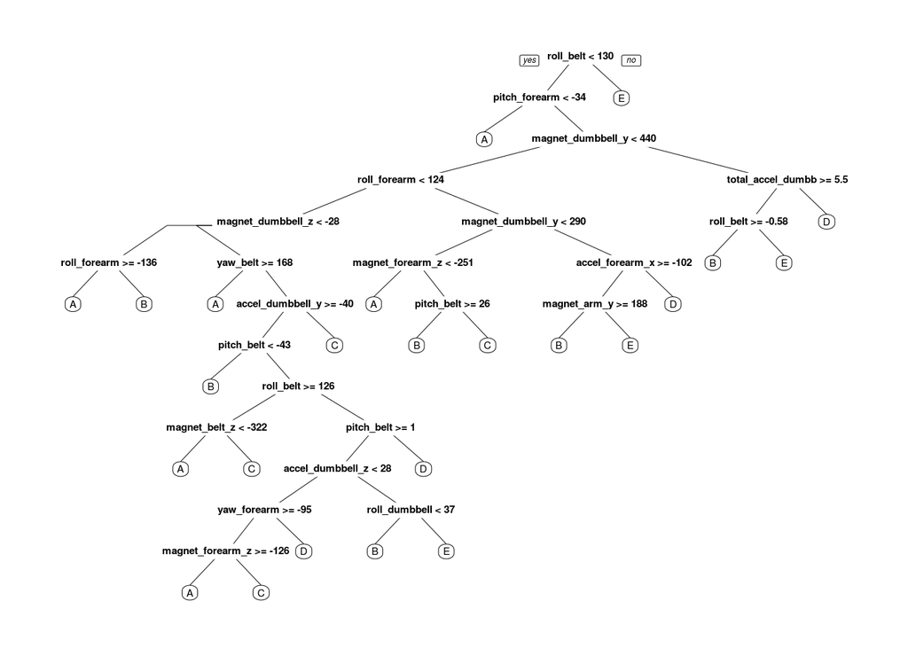

```r
treeModel <- rpart(classe ~ ., data = training_data, method="class")
prp(treeModel) # fast plot
```